# 15-1-1 checks

Emma Wood

27/07/2021

## 15-1-1 update summary

Data for 2004 to 2021 have been created and saved as 2021-07-28_15-1-1.csv in the 15-1-1 Output folder.

### Check configurations

Please check that the information below is as you expect. In particular, pay attention to the time since data were saved, to check that previously downloaded data have not accidentally been used.

These settings can all be adjusted in `config.R`

Files used to create the new data were downloaded and saved in 15-1-1/Input.

**Woodland data from Forest Research**  
Woodland area data are in the file PWS_2021.xlsx.

This file was saved at 2021-07-27 13:38:39: It has been 0.94 days since the file was saved in Input

The tab used for ‘all woodland’ areas is called Data for figure 1, and the tab used for certified woodland area is called Data for figure 2.

**Country area data from the geoportal**  
Total area for countries is in the file SAM_CTRY_DEC_2020_UK.csv

This file was saved at 2021-07-27 13:46:10: It has been 0.94 days since the file was saved in Input

### Check data

The charts below show the new data (just created) plotted on top of the old data, which has been downloaded from the live site. If there are unexpected discrepancies in the lines please investigate the reasons for these discrepancies.

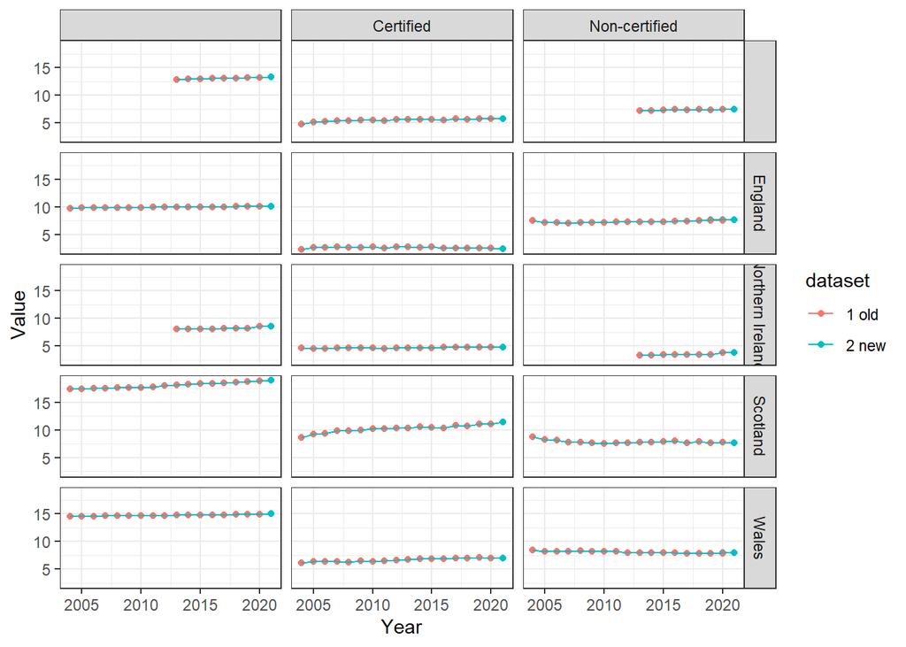

### Calculations done

The calculations used to create these data were:

```
indicator_data <- all_data %>%
  mutate(woodland_proportion = (woodland_area * 1000000) / AREALHECT * 100,
         certified_proportion = (certified_area * 1000000) / AREALHECT * 100,
         non_certified_proportion = ((woodland_area - certified_area) * 1000000) / AREALHECT * 100)
```

Warning: This is copied from `update_15-1-1.R` and will not dynamically update if that code is changed.

### Analysis

At the time of writing this markdown doc, 15-1-1 contains some extra stats in the free text at the top of the indicator page.

These are as follows:

- 43.8% of woodland area in the UK is certified as sustainably managed
- Since the adoption of the SDGs in 2015, woodland area as a percentage of total land area has increased by 2.4%
- Area of woodland in the UK: taken from the woodland statistics bulletin  
  which represents the following percent of land area in each country:

| Year | Country | Value |
| --- | --- | --- |
| 2021 | England | 10.1 |
| 2021 | Wales | 15.0 |
| 2021 | Scotland | 19.0 |
| 2021 | Northern Ireland | 8.6 |
| 2021 | UK | 13.3 |

Further analysis could be reported (and added to this file), but just sticking with what we already had for now.